# Data Wrangling and Visualization in R

January 25, 2018

## Agenda

- Introducing the Tidyverse
- Introducing the Grammar of Graphics (`ggplot2`)
- Going Wider and Deeper

## Introducing the Tidyverse

- Data preparation consumes 80% of your time, so wouldn't it be nice if there were an *intuitive and idiomatic* way of wrangling data?
- Hadley Wickham, a computer scientist and statistician, invented the "tidy" approach to data handling with this aim and created a suite of libraries for R to implement it — now known as the "tidyverse" (or jokingly, the "Hadleyverse"). Here's Hadley:

[figure not shown]

## More motivation

- The "tidyverse" has become the industry-standard in the R-using data science community.
- There is an analogy in Python to the `numpy` and `pandas` suite.
- If you've tried to learn and use `dplyr`, `tidyr`, `ggplot2`, or other Tidyverse affiliates, in the past and became frustrated … I have been in your shoes and this tutorial is especially for you.

## Introducing the Grammar of Graphics

- Leland Wilkinson extended this unified, idiomatic approach to data *visualization* with his book "The Grammar of Graphics."
- A grammar is a set of guidelines for how to combine components to create new things. For example, we combine a noun and verb to make a sentence: "the dog runs". Or you combine butter, eggs, sugar and flour to make a cupcake.

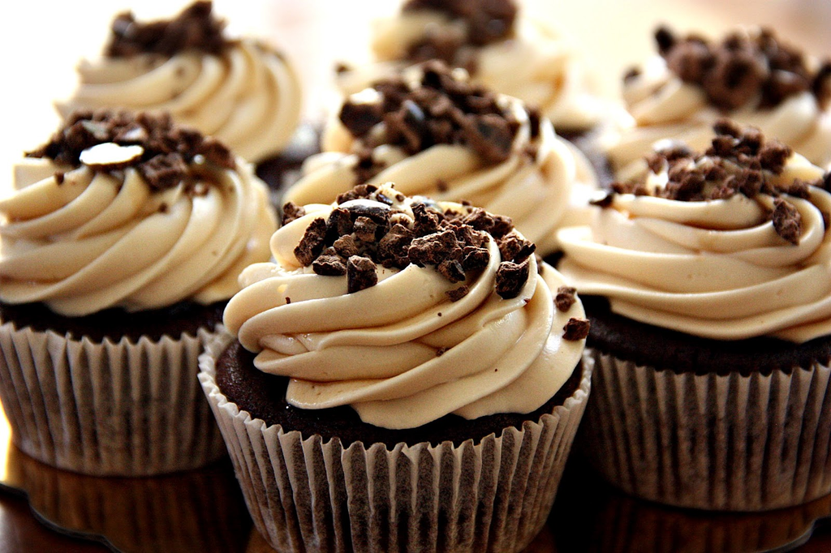

## `ggplot`

- In visualization, we will speak of combining:
1. `data`. Our base ingredient, usually a `data.frame` or `tibble`.
2. `aes`thetic mapping. The map of the data to the visualization; for example, "price on the x-axis".
3. `geom`etry. The shapes of the visualization: point, line, bar, …
4. `stat`istical transformation. How should the data be transformed or aggregated before visualizing.
5. `theme`. Flavoring.

## Going Wider and Deeper with `tidyr`

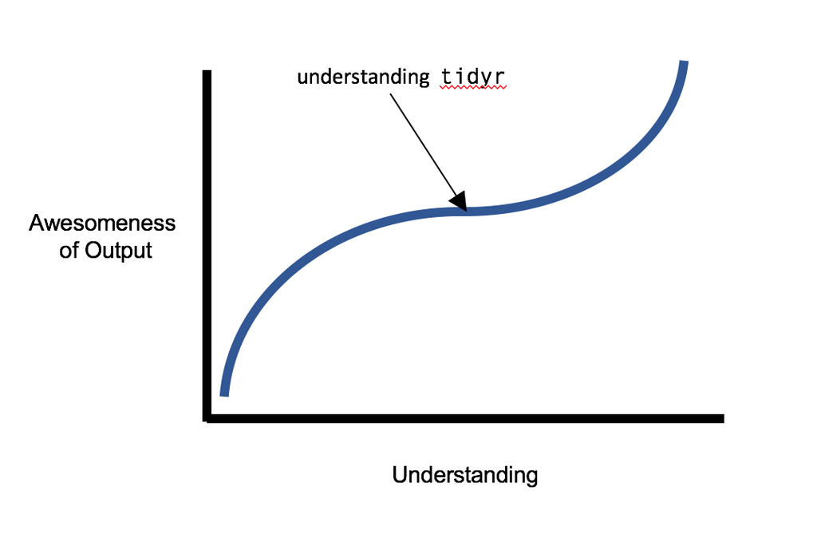

## Understanding the Philosophy

The unifying philosophy of "tidy data" is:

- Each row is an observation
- Each column is a variable
- Each table is an observational unit

Simple, right? Yet a lot of data isn't formed that way.

Consider the following table:

| Company | Qtr.1 | Qtr.2 | Qtr.3 | Qtr.4 |
| --- | --- | --- | --- | --- |
| ABC | $134.01 | $256.77 | $1788.23 | $444.37 |
| XYZ | $2727.11 | $567.23 | $321.01 | $4578.99 |
| GGG | $34.31 | $459.01 | $123.81 | $5767.01 |

This looks completely acceptable, and is a compact way of representing the information. However, if we are treating "quarterly earnings" as the observed value, then this format doesn't really follow the tidy philosophy: notice that there are multiple prices (observations) on a row, and there seems to redundancy in the column headers…

In the tidyverse, we'd rather have the table represent "quarterly earning," with each row giving a single observation of a single quarter for a single company, and columns representing the company, quarter, and earning. Something like this:

| Company | Quarter | Earnings |
| --- | --- | --- |
| ABC | Qtr.1 | $134.01 |
| ABC | Qtr.2 | $256.77 |
| ABC | Qtr.3 | $1788.23 |
| … | … | … |

This is also called the **wide** vs. the **long** format, and we will soon see why it is such a crucial point.

## Gather and Spread

Here's the quarterly earnings table again as a `data.frame` named `earnings`:

```r
earnings
```

```
##   Company Qtr.1 Qtr.2 Qtr.3 Qtr.4
## 1     ABC   134   256  1788   444
## 2     XYZ  2727   567   321  4578
## 3     GGG    34   459   123  5767
```

## Gather

Now we `gather` it up into a **long** format by setting our new "key" column (Quarter), our new "value" column (Earnings), and specifying where to get that information from in the original table (everywhere but the Company column):

```r
long.earnings = earnings %>%
  gather(key=Quarter, value=Earnings, -Company)

long.earnings %>% head()  # take a peek
```

```
##   Company Quarter Earnings
## 1     ABC   Qtr.1      134
## 2     XYZ   Qtr.1     2727
## 3     GGG   Qtr.1       34
## 4     ABC   Qtr.2      256
## 5     XYZ   Qtr.2      567
## 6     GGG   Qtr.2      459
```

## Spread

We can take a long format and `spread` it back out into **wide** format by specifying again the "key" column and the "value" column:

```r
long.earnings %>% spread(key=Quarter, value=Earnings)
```

```
##   Company Qtr.1 Qtr.2 Qtr.3 Qtr.4
## 1     ABC   134   256  1788   444
## 2     GGG    34   459   123  5767
## 3     XYZ  2727   567   321  4578
```